# JSC370 Midterm: Daily PM2.5 and Weather Conditions Across Major U.S. Metropolitan Areas in 2024

Author

Yukun Wang

github link: https://github.com/NKwyk/JSC370-project.git

## Project Introduction (10 points)

PM2.5, or fine particulate matter with aerodynamic diameter less than or equal to 2.5 micrometers, is an important air pollutant because elevated concentrations are associated with worse respiratory and cardiovascular health outcomes. Understanding how PM2.5 changes across time and place is therefore an important public-health and environmental question.

This project studies **daily PM2.5 patterns across major U.S. metropolitan areas in 2024** by combining daily monitor-level PM2.5 data from the EPA AQS platform with daily weather-related variables from NOAA national center. To satisfy the project requirement of using an API, I use the **NOAA Climate Data Online (CDO) Web Services API v2** to retrieve daily **temperature** and **precipitation** data. I then combine those API-based weather measures with daily **wind**, **barometric pressure**, and **relative humidity/dew point** summary files downloaded from the AQS platform.

The main research question is:

**How are daily PM2.5 levels associated with temperature, precipitation, wind, barometric pressure, and humidity-related conditions across major U.S. metropolitan areas in 2024?**

More specifically, I ask:

1. Which metropolitan areas show higher average daily PM2.5 levels in 2024?
2. How does PM2.5 vary across months and seasons?
3. Are higher-PM2.5 days associated with different weather conditions?

The merged analytical panel was constructed at the site-day level for AQS monitoring locations, with NOAA weather variables attached at the CBSA-day level using cbsa_name and date_local. Additional preprocessing was then applied before descriptive tables and figures to address duplicate monitor representations.

## Methods (20 points)

### Data sources

This project combines five daily datasets:

1. **EPA AQS daily PM2.5** (`daily_88101_2024.csv`) as the main outcome dataset.
2. **NOAA CDO API** for daily temperature and precipitation.
3. **EPA AQS daily wind** (`daily_WIND_2024.csv`).
4. **EPA AQS daily barometric pressure** (`daily_PRESS_2024.csv`).
5. **EPA AQS daily relative humidity / dew point** (`daily_RH_DP_2024.csv`).

The AQS daily PM2.5 file contains one row per monitor-day observation, including the daily arithmetic mean, daily maximum value, date, and geographic identifiers such as city and CBSA. The weather-related AQS files have a similar structure. The AQS daily PM2.5 file contains one row per monitor-day observation, and the supplemental AQS weather files have a similar structure. To avoid duplicate monitor records within the same site and day, I first organize the AQS data at the site-day level before merging the supplemental AQS variables. NOAA weather variables are then joined at the CBSA-day level using cbsa_name and date_local.

The NOAA API portion is included to meet the requirement that the project use an API. I use the CDO Web Services v2 endpoint with a token in the request header and retrieve daily weather observations from selected stations corresponding to major metropolitan areas.

### Variable construction

For PM2.5, the key outcome variable is the daily **arithmetic mean** concentration. I also create a binary **high PM2.5 day** indicator for exploratory analysis using a threshold of 35 µg/m³ at the CBSA-day level:

- `high_pm25_day = 1` if daily CBSA mean PM2.5 ≥ 35
- `high_pm25_day = 0` otherwise

For weather, I use:

- `TMAX`: daily maximum temperature from NOAA
- `TMIN`: daily minimum temperature from NOAA
- `PRCP`: daily precipitation from NOAA
- `wind_mean`: daily mean wind speed from AQS daily wind
- `press_mean`: daily mean barometric pressure from AQS daily pressure
- `rh_mean`: daily mean relative humidity from AQS daily RH / dewpoint

### Cleaning and preprocessing

The preprocessing workflow is:

1. Read all daily files.
2. Standardize column names to lower snake_case.
3. Parse dates.
4. Remove observations with missing CBSA or missing key outcome values.
5. Aggregate the AQS datasets to the site-day level using site identifiers and date.
6. Merge AQS sources by site-day keys, then attach NOAA weather by cbsa_name and date_local.
7. Create month, season, and high-pollution indicators.

### Planned analyses

I use exploratory data analysis and summary statistics to describe temporal and spatial patterns in PM2.5. Specifically, I examine:

- monthly and seasonal PM2.5 patterns
- mean PM2.5 by CBSA
- top metropolitan areas by annual average PM2.5
- relationships between PM2.5 and weather variables using scatterplots and grouped summaries

For the final project, this merged dataset could also support a predictive model for daily PM2.5 or high-PM2.5 days.

To begin the analysis, the primary environmental datasets are loaded into the environment. These comprise four separate daily summary files downloaded directly from the EPA Air Quality System (AQS) platform for the year 2024: the main outcome variable (PM2.5) and three supplementary meteorological variables (wind, barometric pressure, and relative humidity/dew point). These raw .csv files serve as the foundational monitor-level observations for the study.

### Data generation and api retrieval

To satisfy the project’s requirement of utilizing an Application Programming Interface (API) and to obtain essential meteorological covariates, I integrate daily weather data from the NOAA Climate Data Online (CDO) Web Services API v2.

Then I design a suite of custom helper functions is defined to interact robustly with the API endpoints. The noaa_get function manages authentication via a unique request token and handles potential connection errors.

Because of the NOAA API limits the number of records returned per request, the fetch_noaa_data function is designed with a pagination loop (using the offset parameter) to iteratively pull all available rows for a given station and date range. Additional functions are included to verify station validity and extract available datatypes.

The NOAA CDO API queries data at the individual weather station level rather than by city. To align this weather data with the AQS pollution data, I construct a mapping dictionary (metro_station_map). This dictionary links major U.S. Core Based Statistical Areas (CBSAs)—such as New York, Los Angeles, and Chicago—to the specific Global Historical Climatology Network Daily (GHCND) station ID that best represents the metropolitan area’s general weather conditions.

With the API helper functions and the CBSA-to-station mapping established, the data retrieval process is executed. The code iterates through the predefined dictionary of major metropolitan areas, calling the fetch_noaa_weather_bundle function for each station. Specifically, it requests daily maximum temperature (TMAX), minimum temperature (TMIN), and precipitation (PRCP) for the entire year of 2024. The successfully retrieved records are appended into a single, long-format DataFrame (noaa_weather_raw), which is later reshaped and merged with the EPA AQS datasets.

### Data cleaning and wrangling

#### Standardize column names

To ensure consistency across the multiple EPA AQS datasets, the first step in the data wrangling process is to standardize all column names. The clean_columns function converts all headers to lowercase, strips trailing whitespaces, and replaces spaces and special characters with underscores (snake_case format). This step minimizes referencing errors during the merging phase.

#### Parse dates

Next, the date columns across all four datasets (PM2.5, Wind, Barometric Pressure, and Relative Humidity) are converted from string format to pandas datetime objects. The dt.normalize() function is applied to strip any inconsistent timestamp information, ensuring that all dates are standardized at midnight for accurate daily merging.

#### Build location-day datasets

A key challenge with the AQS datasets is the presence of multiple Parameter Occurrence Codes (POC) at a single monitoring site on the same day. These represent multiple instruments operating simultaneously. To handle this and create a clean unit of observation, I construct a unique location-day identifier (location_day_keys) using state_code, county_code, site_num, and date_local.

The aggregate_to_location_day function is then applied to group the data by these unique keys. If a site has multiple monitors, the function calculates the mean of the daily arithmetic means, collapses the geographic identifiers, and returns a dataset strictly at the site-day level.

#### Merge AQS supplemental data and NOAA weather

With all datasets aggregated to the site-day level, I conduct a sequence of merges to build the final comprehensive dataset. First, the AQS meteorological variables (wind, pressure, humidity) are joined to the main PM2.5 dataset using the location_day_keys via a one-to-one left merge.

Subsequently, the NOAA API weather dataset, which is constructed at the broader Core Based Statistical Area (CBSA) level, is integrated. To achieve this, I reshape the NOAA data into a wide format (weather_wide) with one row per CBSA-day. This dataset is then merged into the site-level AQS panel using a many-to-one left join based on cbsa_name and date_local. Finally, new categorical variables such as month, season, and a binary indicator for high_pm25_day (≥ 35 µg/m³) are generated to facilitate exploratory data analysis.

The final preprocessing step involves handling missing values to prepare the dataset for complete-case analysis. Because the NOAA API data was pulled exclusively for specific major metropolitan areas, AQS monitors located outside these CBSAs lack temperature and precipitation data. Furthermore, some monitors may have missed recording certain meteorological parameters on given days. Therefore, I subset the data by removing any rows containing missing values across the core variables, yielding the final analytical dataset (merged_local_day).

Before producing the descriptive tables and figures, I applied an additional preprocessing step to handle cases where multiple POCs appeared within the same site-day record.

## Preliminary Results (30 points)

### Basic dataset summary

After merging the datasets, I found that some site-day records still contained multiple POC values. In the AQS system, POC is used to distinguish different monitors measuring the same parameter at the same site, rather than to indicate a specific measurement method or a “primary” monitor. For this exploratory report, I restricted the descriptive analysis to records with POC = 1 as a pragmatic rule to simplify duplicate site-day records. This rule was used only to reduce duplicate monitor representations and should not be interpreted as identifying a primary monitor or a specific measurement method.. Then we can do a small summary for the data:

Table 1: Table 1: Summary Statistics of PM2.5 and Weather Variables (Primary Monitors Only)

|  | count | mean | std | min | 50% | max |
| --- | --- | --- | --- | --- | --- | --- |
| PM2.5 Mean (µg/m³) | 5798.0 | 9.76 | 6.68 | 0.00 | 8.53 | 130.94 |
| Max Temp (°C) | 5798.0 | 20.78 | 9.04 | -16.00 | 21.10 | 47.80 |
| Precipitation (mm) | 5798.0 | 1.96 | 7.12 | 0.00 | 0.00 | 109.70 |
| Wind Speed Mean | 5798.0 | 99.09 | 31.00 | 3.91 | 101.29 | 321.08 |
| Barometric Pressure (mb) | 5798.0 | 991.62 | 29.61 | 823.04 | 994.67 | 1044.21 |
| Relative Humidity (%) | 5798.0 | 64.35 | 18.51 | 5.71 | 67.62 | 100.00 |

The summary statistics for the 5,798 site-day observations provide a foundational understanding of the 2024 dataset: - PM2.5 Concentrations: The average daily PM2.5 concentration (arithmetic_mean) is 9.76 µg/m³. However, the mean is higher than the median (8.53 µg/m³), indicating a right-skewed distribution caused by extreme pollution events, with a recorded maximum of 130.94 µg/m³. - Temperature Ranges: Maximum temperatures (TMAX) average 20.78°C, but the dataset captures significant extremes ranging from -16°C to 47.8°C. This wide variation ensures that the study accounts for diverse seasonal impacts on air quality. - Precipitation and Humidity: Precipitation is highly skewed, with a median of 0.0 mm, indicating that most days in the sample are dry. The average relative humidity of 64.35% suggests moderate atmospheric moisture levels across the metropolitan areas studied. - Atmospheric Pressure: Barometric pressure remains stable with a mean of 991.62 mb. The minimum of 823.04 mb correctly reflects data from high-altitude monitoring sites, adding to the geographic diversity of the report.

### Temporal Patterns: Monthly and Seasonal PM2.5

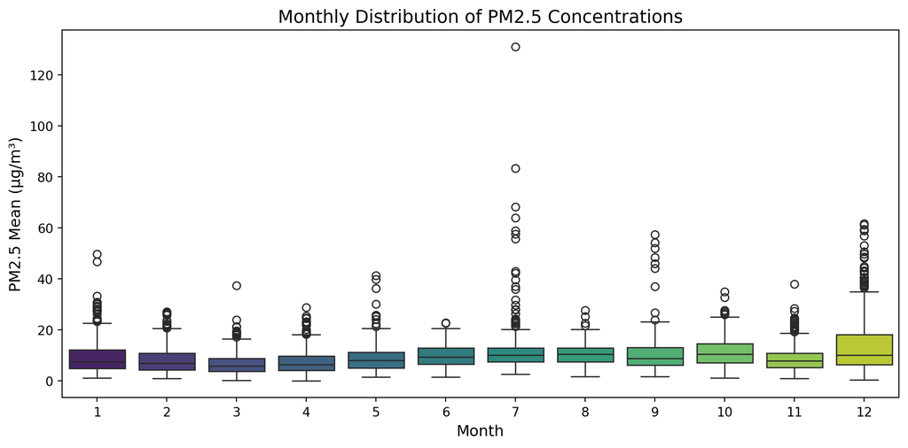

Figure 1: Figure 1: Monthly Distribution of Daily PM2.5 Concentrations in 2024

Table 2: Table 2: Seasonal Summary of PM2.5 Concentrations

| season | count | mean | std | max |
| --- | --- | --- | --- | --- |
| Fall | 1415 | 10.14 | 6 | 57.46 |
| Spring | 1520 | 7.75 | 4.72 | 41.4 |
| Summer | 1484 | 10.67 | 6.5 | 130.94 |
| Winter | 1379 | 10.62 | 8.63 | 61.7 |

The seasonal summary table quantifies the temporal fluctuations of PM2.5 concentrations throughout 2024: - Peak Pollution Periods: Summer and Winter emerge as the seasons with the highest average concentrations, recording means of 10.67 µg/m³ and 10.62 µg/m³, respectively. - Extreme Events: Summer recorded the most severe pollution event of the year, with an absolute maximum of 130.94 µg/m³, nearly triple the maximum observed in Spring. - Variability: Winter exhibits the highest standard deviation (8.63), indicating that air quality during this period is the most volatile, likely due to intermittent stagnation and temperature inversion events. - Cleanest Season: Spring is established as the cleanest period of the year, characterized by the lowest average concentration (7.75 µg/m³) and the lowest variability (std of 4.72).

### Spatial Patterns: Top Metropolitan Areas

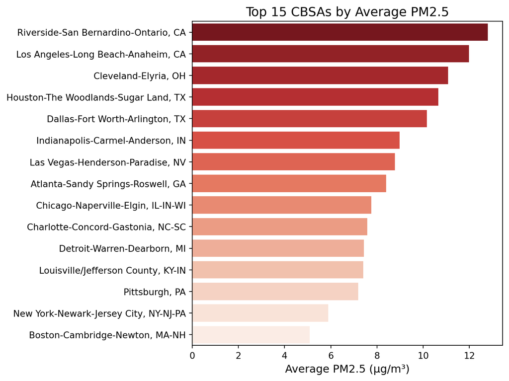

Figure 2: Figure 2: Top 15 Metropolitan Areas by Average Daily PM2.5

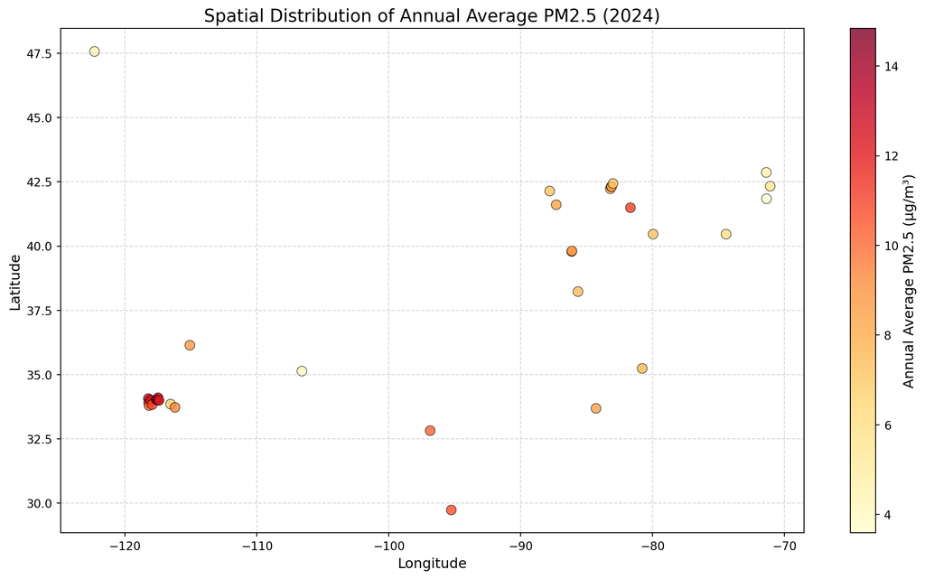

Figure 3: Figure 3: Spatial Distribution of Annual Average PM2.5 across U.S. Monitoring Sites

### Weather and PM2.5 Relationships

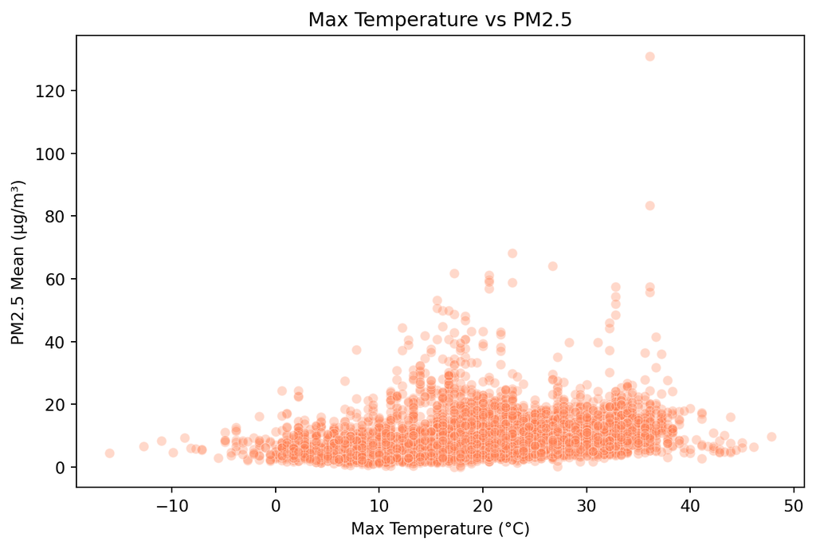

Figure 4: Relationship between Daily Maximum Temperature and PM2.5

The scatterplot reveals a significant non-linear relationship between maximum daily temperature (TMAX) and PM2.5 concentrations. While the majority of observations cluster at lower concentrations across all temperatures, the most severe pollution spikes (above 60 µg/m³) occur exclusively within the 15°C to 40°C range. This suggests that moderate-to-high temperatures are a key environmental prerequisite for extreme PM2.5 events in this dataset. These spikes are likely driven by enhanced secondary aerosol formation through photochemical reactions or seasonal events like summer wildfires, whereas extreme cold or extreme heat (>45°C) appears to limit the potential for such high-concentration peaks.

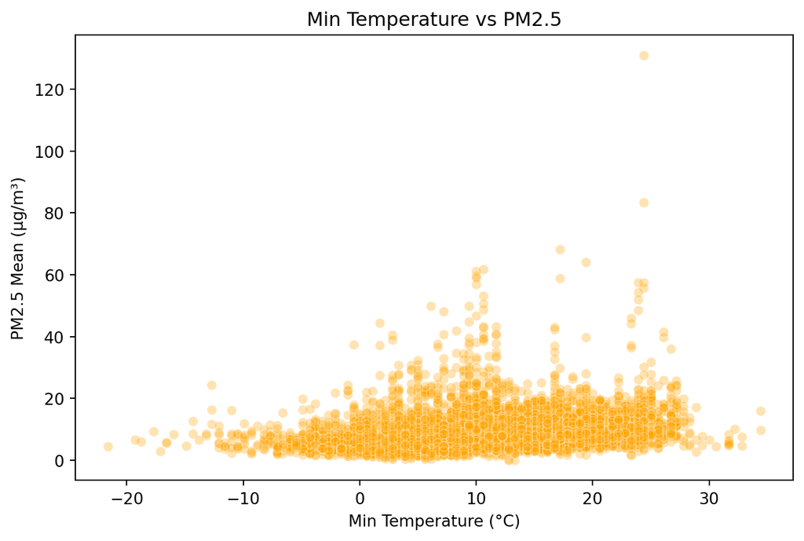

Figure 5: Relationship between Daily Minimum Temperature and PM2.5

The relationship between daily minimum temperature (TMIN) and PM2.5 concentrations reveals significant seasonal clustering. Most extreme pollution spikes (exceeding 60 µg/m³) are observed when the daily minimum temperature falls between 10°C and 25°C, which aligns with the previously identified high-pollution periods in summer and early autumn. Interestingly, while the data shows a broad distribution, very low minimum temperatures (below 0°C) exhibit relatively fewer extreme outliers compared to the moderate temperature range. This suggests that in the sampled metropolitan areas, the most hazardous air quality events are more closely tied to warm-season stagnant air masses or specific regional events (like wildfire smoke) rather than cold-weather temperature inversions alone.

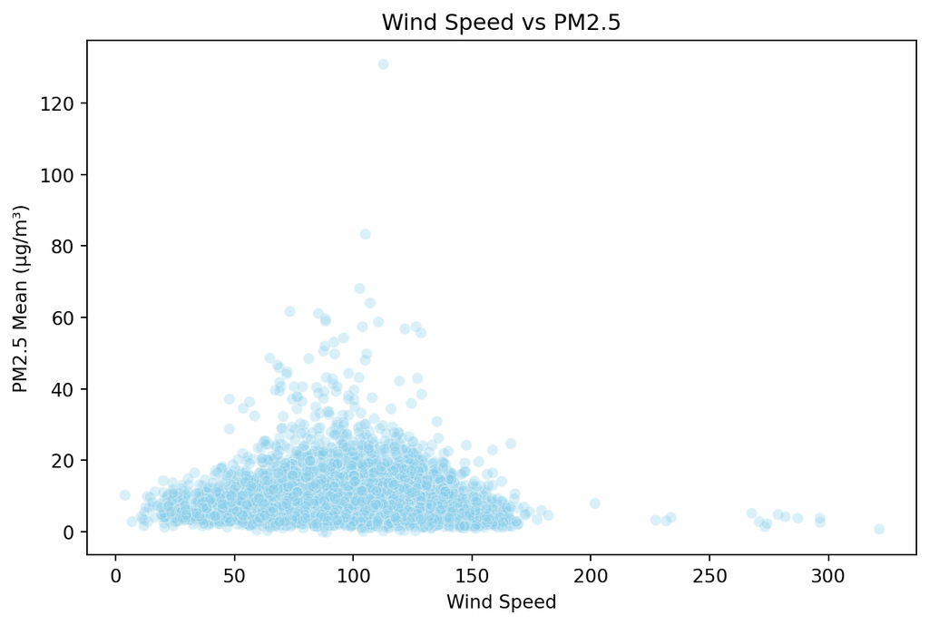

Figure 6: Relationship between Wind Speed and PM2.5

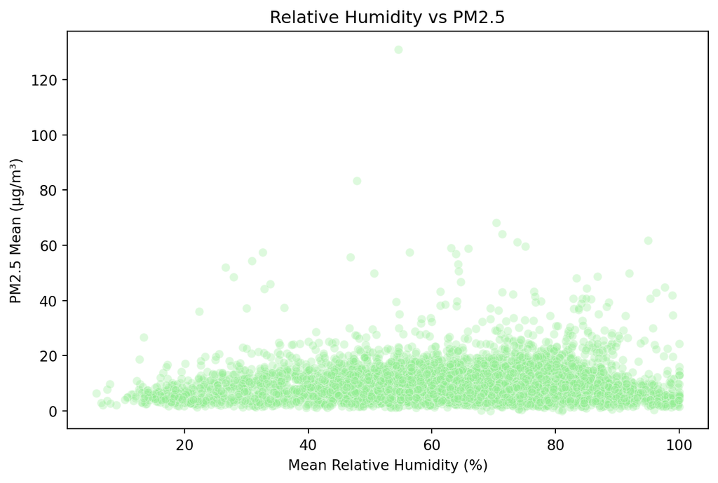

Figure 7: Relationship between Relative Humidity and PM2.5

The scatterplot confirms a significant, non-linear relationship between relative humidity (RH) and PM2.5 concentrations. There should be some physical properties we can relate to under this condition:

- Hygroscopic Growth Effect: A dense cluster of high PM2.5 observations is evident in the 40% to 80% RH range. This is a direct physical consequence of hygroscopic growth, where existing fine particulate matter absorbs atmospheric water vapor, increasing its mass and size, and thus raising the recorded concentration.
- The Upper Threshold: Interestingly, as humidity approaches saturation (90%–100%), the concentration of PM2.5 tends to decrease. This is likely due to the fact that near-100% humidity is often associated with fog formation or precipitation events (the washout effect), which removes particles from the air.
- Limiting Factors: The scarcity of extreme PM2.5 spikes at very low humidity (<20%) suggests that moisture is often a necessary “facilitator” for reaching high aerosol mass concentrations in many urban environments.

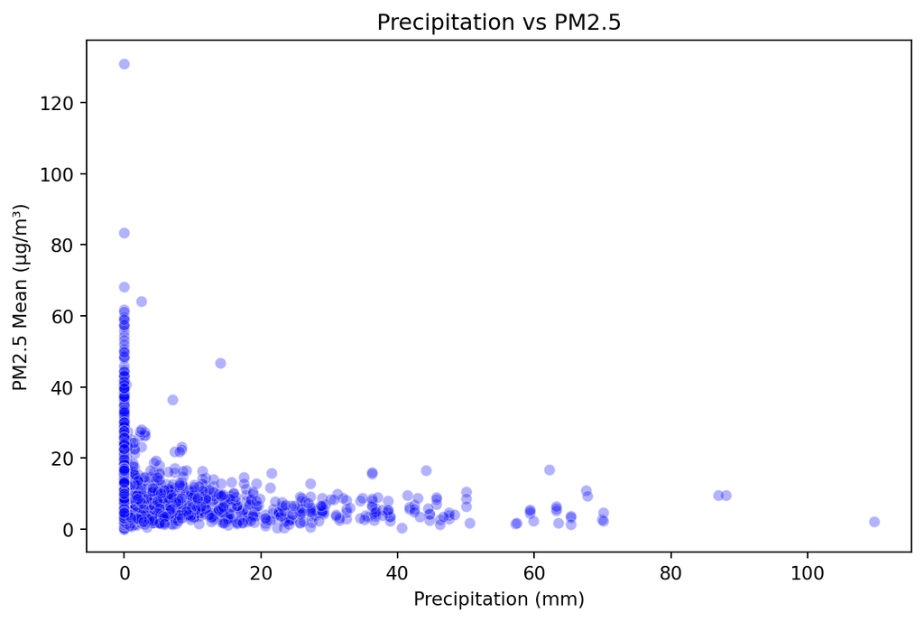

Figure 8: The Washout Effect: Precipitation vs PM2.5

This confirms that rainfall acts as a primary natural cleanser of the atmosphere, physically removing fine particulate matter through wet deposition. The lack of high-pollution outliers during rainy periods highlights that dry, stagnant weather is a mandatory prerequisite for hazardous PM2.5 accumulation in these urban areas. Also the rainfall have the direct connection with the relative humidity above.

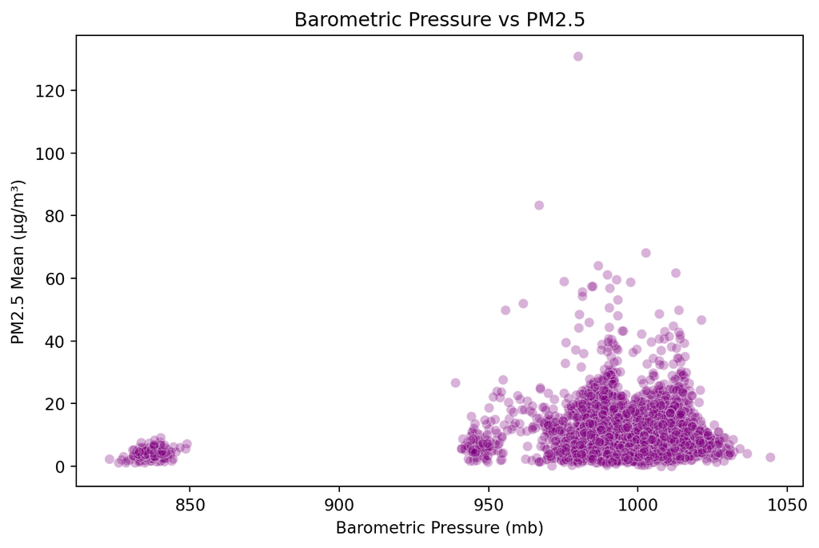

Figure 9: Relationship between Barometric Pressure and PM2.5

## Summary (15 points)

### Answer to the proposed research questions

The EDA reveals that PM2.5 concentrations are governed by non-random temporal, spatial, and meteorological patterns. Most notably, the relationship between weather variables (like humidity and precipitation) and air quality is predominantly non-linear. This complexity provides a strong empirical justification for utilizing advanced machine learning algorithms rather than simple linear regressions for the final forecasting phase.

### Final Project Objectives

The final project will transition from descriptive analysis to predictive modeling, focusing on a two-pronged Machine Learning strategy:

- Regression Modeling: To predict the precise daily arithmetic_mean of PM2.5. This will be used to understand the exact sensitivity of air quality to incremental changes in weather parameters.
- Classification Modeling: To categorize air quality into discrete risk levels (e.g., based on AQI thresholds: Good, Moderate, Unhealthy). This approach is more aligned with public health decision-making, where the goal is to trigger alerts rather than predicting exact concentrations.

### Implementation Plan

To achieve these objectives, the following steps will be executed:

Step 1: Feature Engineering & Pre-processing: Handle the cyclical nature of wind direction using trigonometric transformations (sine/cosine). Also integrate temporal features (month, day of week) and regional indicators to capture localized trends.

Step 2: Model Development & Selection: We will evaluate non-linear models such as Random Forest, XGBoost, or Support Vector Machines (SVM) to handle the complex interactions identified in the scatterplots. For Classification, we will implement multi-class classifiers to predict AQI categories.

Step 3: Interactive Visualizations: Develop an interactive dashboard (using Plotly or Leaflet) that allows users to explore PM2.5 levels across the U.S. in real-time.

Step 4: Web Development: The entire analysis and the trained models will be hosted on a dedicated website (via Quarto Pub or GitHub Pages), providing an accessible platform for stakeholders to interact with our predictive tools.